# Assignment 0

Mooven Soobaroyen

Jan 31, 2016

# **ASSIGNMENT 0 - SRT 411**

Student Information :

- Github name : mooven
- Name : Mooven Soobaroyen
- Student No : 042-853-143

# **Introduction**

In this assignment, I will be creating a document using knitr to publish my report for assignment 1 on Github. I used Rstudio to write my code. This assignment contains all the ToDos in the “short introduction to R”. I will be doing them in order as per the link provided.

# **ToDo**

**- `ToDo 1`**

This is the first ToDo which consists of calculating the percentage of my life I have spent at college. The current year is 2016, I started college in 2014 and I was born in 1995. The percentage is calculated as shown:

```r
((2016-2014)/(2016-1995))*100
```

```
## [1] 9.52381
```

As shown above by the calculation, we can see that the percentage I have spent at college of my life is 9.52381%.

**- `ToDo 2`**

Here I will be calculating the percentage of my life I have spent at college just as the one above, but this time I will be using variables.

```r
UniYear = (2016-2014) #Defining the numbers of years I have spent at school as UniYear
MyAge = (2016-1995) #The variable MyAge is for my age
Percentage = ((UniYear/MyAge) * 100) #Percentage is the variable to give the percentage
Percentage #calling the variable
```

```
## [1] 9.52381
```

As you can see the answer is the same. It is just this time we are making use of variables.

**- `ToDo 3`**

Here we will be creating a vector with the numbers 4,5,8 and 11. We will then proceed to calculate the sum of the vector.

```r
x=c(4, 5, 8, 11) #saving the vector as a variable called x
sum(x)
```

```
## [1] 28
```

The sum of the vector is 28 as shown above which is 4 + 5 + 8 + 11.

**- `ToDo 4`**

We will now generate 100 random numbers using the function rnorm and plot the 100 numbers on a graph.

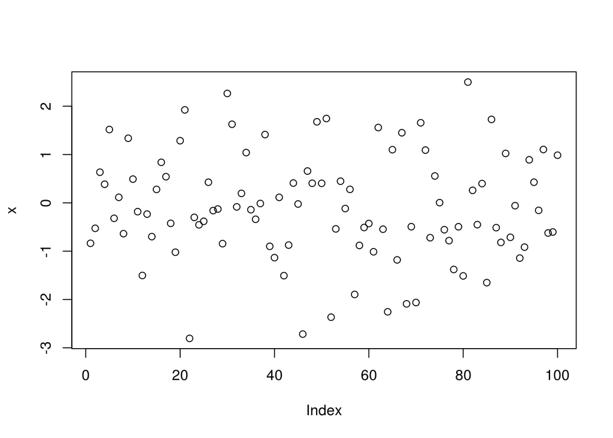

```r
x = rnorm(100) #saving the 100 numbers as a variable called x
plot(x) # plotting the graph
```

The graph once plotted is as shown below. We will show in the later steps how to plot graphs using different colors and different size and symbols of coordinates.

**- `ToDo 5`**

We will now be using the help command which tells us what does a particular function. The following example shows the help command on the square root function (sqrt).

```r
help(sqrt)
```

**- `ToDo 6`**

In this step we will be saving the code for ToDo 4 as a script namely ‘firstscript.R’. We will then be showing how to use the source command in calling a script.

```r
source("firstscript.R")
```

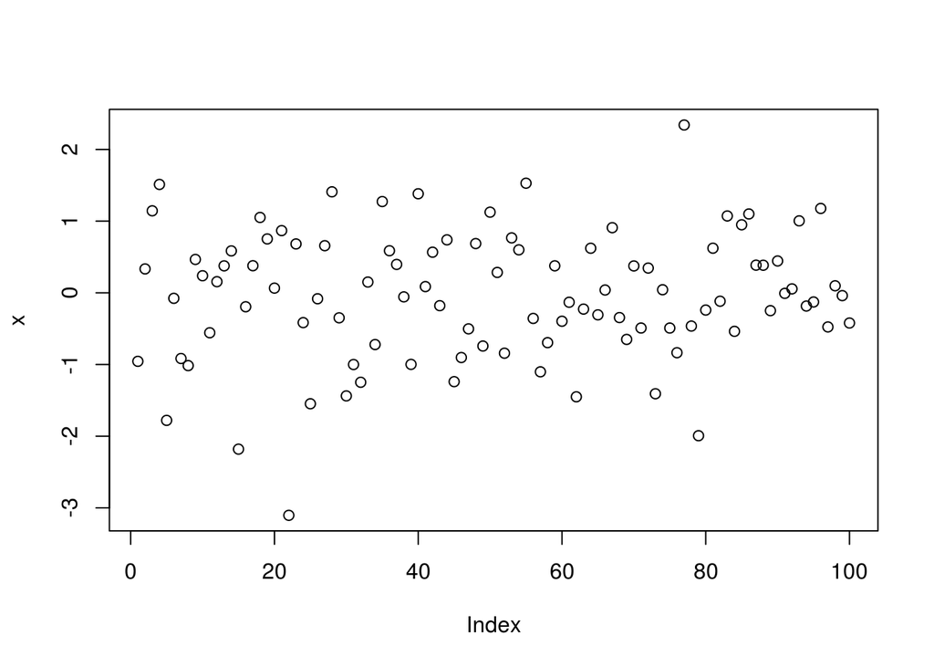

**- `ToDo 7`**

Here I will be creating a vector called ‘P’ which consists of numbers starting from 31 to 60 that is altogether 30 numbers. I will then create a matrix with it and save it in a variable namely ‘Q’. The matrix will be consisting of 6 rows and 5 columns. The code is as shown below.

```r
Q = matrix((P = seq(from=31, to=60, by=1)), nrow=6, ncol=5)
Q # calling the variable Q that is the matrix
```

```
##      [,1] [,2] [,3] [,4] [,5]
## [1,]   31   37   43   49   55
## [2,]   32   38   44   50   56
## [3,]   33   39   45   51   57
## [4,]   34   40   46   52   58
## [5,]   35   41   47   53   59
## [6,]   36   42   48   54   60
```

The matrix is as shown above consisting of 6 rows and 5 columns.

**- `ToDo 8`**

```r
#Create the 3 vectors x1,x2 and x3 of length 100
x1 = c(rnorm(100))
x2 = c(rnorm(100))
x3 = c(rnorm(100))
#Calling the vectors
x1
```

```
##   [1] -1.205757565 -1.940456417 -1.817925755  0.149495927 -1.950039358
##   [6]  0.017929104 -0.669409671 -1.627886488 -1.043620566 -0.905578774
##  [11] -0.257818885  1.202901988  0.530902525  0.412585622 -1.124320072
##  [16]  1.607935300 -0.180074986 -0.029956764  0.055267066 -0.401108173
##  [21] -0.277283519  0.267774689  0.608739029  0.699818609  0.016742097
##  [26]  1.621605259 -0.222156654  0.296950468  1.213145299 -0.950607821
##  [31]  0.048594661 -0.024194988  0.328005923 -0.884195245  2.055247337
##  [36]  0.962177718  0.754131546 -0.512912518 -1.171372080  0.342611545
##  [41] -2.253442194  0.107043581  0.112327554  1.897961833 -1.551529086
##  [46]  0.192271577 -0.820335773  1.368106541  0.407610505  0.370608034
##  [51]  0.137218343  0.415488643 -0.438823651  0.888907322 -0.080727529
##  [56] -0.215204967  0.521733996 -1.701567668  0.420333864  0.068471292
##  [61]  0.345215357  0.681017150  0.721321322 -0.153381720  0.679431144
##  [66] -0.837291220  2.068963393 -0.005460029  0.793248178  0.851737558
##  [71] -3.399275103  0.055089639 -1.457389122 -0.120350628 -2.178352809
##  [76]  1.015636091 -1.169679423  0.862285817 -0.172645150 -0.447412597
##  [81] -0.887597545  0.204714572  1.315912089  0.830998163 -1.766313958
##  [86] -0.980948420 -1.444283688 -1.316887669  0.116387687  0.714521896
##  [91]  1.433961109  0.899264283 -0.173146834  1.715387908 -0.007011715
##  [96] -0.688861334 -0.397775776 -1.828378459 -0.668158440  0.226582881
```

```r
x2
```

```
##   [1]  0.2578746744  0.2860873469  0.2225886828  0.7682609684  0.2270187128
##   [6]  0.3487979499  0.7119676400  0.1964242589  1.9276481159 -1.0226310386
##  [11]  0.2925302469  0.0408513222  0.6623964884  0.2974456900  2.2761411806
##  [16]  0.3559898424 -0.4950289313 -1.4499624853 -1.3663106064 -0.2116959869
##  [21] -1.5830952482  1.4178487511 -0.3288839795 -1.9364953502  1.5385086499
##  [26]  1.3294568692 -0.0976814579  1.2627710068  0.7893150157 -0.2830484866
##  [31]  0.0332102053 -0.7805170931  2.6681417620  2.4617996132  0.0674921911
##  [36] -0.0943365182 -0.6924077359  0.0957114855  0.9041641181  0.8077316901
##  [41] -1.3431746256 -0.2460635381 -0.0346443248  2.1879891224  0.9941387831
##  [46] -1.4335628265  1.3237319764 -0.0094282313 -0.3815186002  0.9559761466
##  [51]  1.9003770943  0.8244530608  1.2148386934  1.0024272528  1.1857189788
##  [56] -1.2877683070  0.4902863618 -1.0379864259  0.0624495076 -0.0924622945
##  [61] -0.9056958574 -1.3712906180  1.2942877537 -1.1859009923 -0.6199103175
##  [66]  0.2413750011  1.1379644502  0.4908588771 -2.4947152496 -1.6384825524
##  [71]  0.8382770706 -0.6999858873 -0.4320790503  0.6665418741 -0.8344884256
##  [76] -0.9948836204  0.4509768095  0.4391361394 -0.0536813643 -0.3643289275
##  [81] -2.0008515854 -0.7752785426  0.0215495865  0.9601539392 -0.3025765092
##  [86] -0.7403887917 -0.0006060756  2.1735675657 -0.4889408838 -2.4711926708
##  [91] -0.7744283278 -0.1101768498 -1.9025694505  0.0024056273 -0.5171170943
##  [96]  1.2163605505 -0.4297610526  0.8487157003 -1.4315830829  0.8802200863
```

```r
x3
```

```
##   [1]  0.52921838  0.91228715 -1.87059217 -0.66638561 -0.79904493
##   [6] -1.42086714 -1.28934018 -0.65259802  0.25717076 -1.90361141
##  [11]  0.20561618 -1.48248864  0.77276369 -0.89079199 -1.94195622
##  [16]  1.27616018 -0.20723487  0.23610014  0.02065578 -0.48495105
##  [21]  1.03104815  1.75422619 -0.99525584 -0.40495649 -2.93301810
##  [26]  1.67596387 -0.31475087 -0.93169923  0.71735501  2.05339010
##  [31] -1.28216888 -0.26543613  0.27536380  0.09252162  1.45713864
##  [36] -0.06236505  0.66293177  0.22832690 -0.08144311  0.40660707
##  [41]  1.19866666 -1.00636732 -0.24109067  1.15389578  0.74573608
##  [46]  1.34201237 -0.05555264 -0.57931669 -1.03825545  1.40484251
##  [51] -0.30722605 -0.75187872  1.27803180 -0.19340659 -0.49148024
##  [56]  2.18666312  0.41438380  0.84121499 -0.28397885 -1.33986757
##  [61]  0.81415747  0.18043578  1.26209113  0.32977216  1.58623931
##  [66]  1.84292712 -1.19391619 -0.43611908 -1.69788369 -1.43996299
##  [71] -1.98989049  1.14164381 -0.79146348 -0.57786130 -0.94966547
##  [76] -0.58029014  1.29246438 -0.05569958  0.58071058  1.67182298
##  [81] -0.19887049  0.05907249 -0.84639302 -0.76223785  0.87746957
##  [86] -1.85700979 -1.13010864 -0.11682235 -0.44605252 -0.05233036
##  [91]  0.39901767 -2.05179410  0.20370445 -0.72446943  1.87277417
##  [96] -1.11423058  0.79964660 -1.51361366 -1.59740257  0.29284263
```

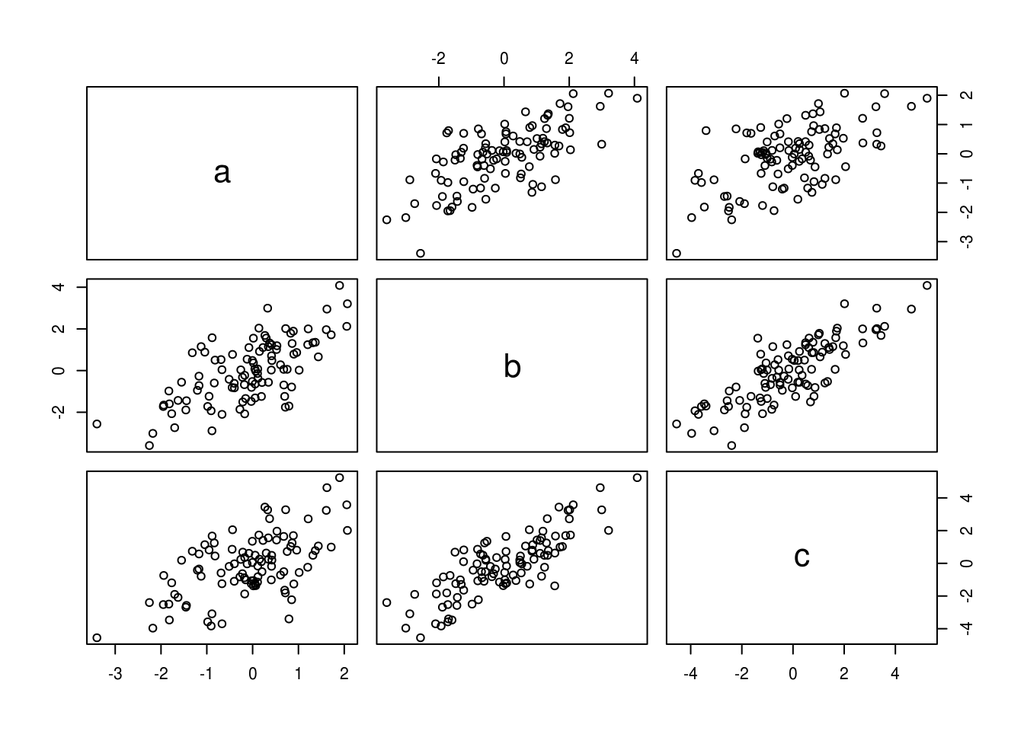

```r
#create a data frame with 3 columns
t = data.frame(a = x1, b = x1+x2, c = x1+x2+x3)
plot(t)
```

**- `ToDo 9`**

Here I will be adding the following lines to the previous ToDo. Check the following:

```
plot(t$a, type="l", ylim=range(t),
lwd=3, col=rgb(1,0,0,0.3))
lines(t$b, type="s", lwd=2,
col=rgb(0.3,0.4,0.3,0.9))
points(t$c, pch=20, cex=4,
col=rgb(0,0,1,0.3))
```

I will now by explaining the meaning of rgb, lwd, pch and cex.

- rgb

rgb stands for Red, Blue and Green. It gives an idea of what color you want the graph to be and playing with the intensity of the colors, you can create the color of your choice. The last argument is for the intensity of the line.

- lwd

Lwd is the thickness of the line. The higher the value, the thicker the line.

- pch

pch (graphic symbol) is the sign of the plot we use to plot the change. Different number is for different shapes of plots such as circles, triangles, cross etc.

- cex

cex (size of pixel) is the size of the coordinates. The higher the number, the bigger the coordinates.

**- `ToDo 10`**

I will then create a script to read it the file and multiply the column ‘g’ by 5 and store the result in a file named as tst2.txt.

```r
 d = data.frame(a = c(1,2,4,8,16,32),
               g = c(2,4,8,16,32,64),
               x = c(3,6,12,24,48,96))
#saving the matrix in a file named as tst1.txt
write.table(d,file="tst1.txt", row.names=FALSE)
#creating a script to call it
read.table(file="tst1.txt", header=TRUE)
```

```
##    a  g  x
## 1  1  2  3
## 2  2  4  6
## 3  4  8 12
## 4  8 16 24
## 5 16 32 48
## 6 32 64 96
```

As you can see above it prints the matrix.

```r
#multiplying the 'g' column by 5
d[2] = d[2]*5
#saving the results as a text file named as tst2.txt
write.table(d,file="tst2.txt", row.name=FALSE)
```

**- `ToDo 11`**

Here I will be calculating the square root of 100 randomly generated numbers.

```r
sqrt(rnorm(100))
```

```
## Warning in sqrt(rnorm(100)): NaNs produced
```

```
##   [1] 0.32622266        NaN 0.74523682        NaN        NaN 0.56280276
##   [7] 0.80460112 0.45601364 0.61623204 0.96030610        NaN 0.47877234
##  [13]        NaN 0.45489238 0.76859034 0.49301357 1.43063101        NaN
##  [19] 0.65094085 0.87010950        NaN 1.32674378        NaN 1.40979670
##  [25] 0.92581677        NaN 1.12589577        NaN 1.26946623 1.00405124
##  [31] 0.35837259 0.67875529 0.76107227 0.93614724 0.08120721        NaN
##  [37] 1.27334360 0.49159683 1.02395838        NaN        NaN 1.13896590
##  [43]        NaN        NaN        NaN 1.39993042 1.01738313 1.02230812
##  [49]        NaN 0.63022964        NaN 0.79493939        NaN 1.43567020
##  [55] 1.19478507        NaN 1.12289759        NaN 0.95493335 0.89604750
##  [61]        NaN        NaN        NaN        NaN        NaN 1.42532818
##  [67] 0.33390802        NaN        NaN        NaN 0.72563157        NaN
##  [73] 0.71168212 1.52592080 0.32151749 1.15313680        NaN 0.48992627
##  [79] 1.08241034        NaN 0.91584316 0.56683761 0.68408031        NaN
##  [85] 1.09507863        NaN 1.01953110        NaN        NaN 0.85185938
##  [91] 0.36939414 0.40317239 1.42468171        NaN        NaN 1.06636363
##  [97] 0.32518107 0.49402054        NaN 0.96458225
```

As you can see it gives a warning saying that NaNs are produced. NaN stands for not a number. It usually means that the output number is a complex number that is it is an imaginary number.

**- `ToDo 12`**

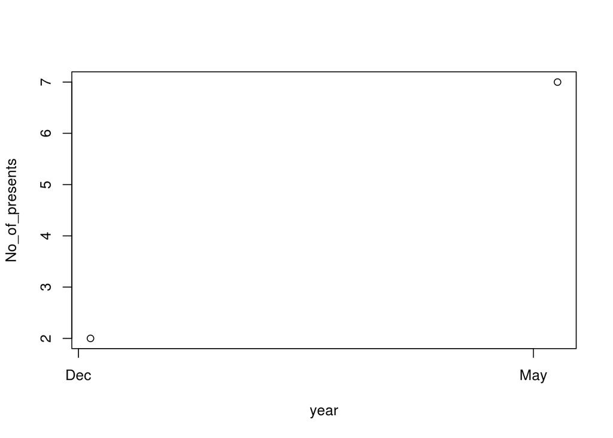

```r
year = strptime(c("20141205", "20150509"),format="%Y%m%d")
No_of_presents = c(2,7)
plot(year, No_of_presents)
```

**- `ToDo 13`**

We will be making a vector from 1 to 100. A for-loop will also be in place which runs through the whole vector. Elements which are smaller than 5 and larger than 90 will be multiply by 10 and the other elements with 0.1. Look at the code below to get an idea of how the code looks like.

```r
f = seq(from=1, to=100) # creating a vector called 'f' with numbers ranging from 1-100
for (i in 1:100)
{
  if (f[i] < 5 | f[i] > 90)
  {
    f[i] = f[i] * 10
  }
  else
  {
    f[i] = f[i] * 0.1
  }
}
```

**- `ToDo 14`**

Here we will be writing the function for the previous ToDo but using an argument so that we can feed it any vector you like. We will also be using a for-loop in the function to do the computation with each element. We will use the standard R function length in the specication of the counter.

```r
vector = function(arg1)
{
  for (i in 1:length(arg1))
  {
    if (arg1[i] < 5 | arg1[i] > 90)
    {
      arg1[i] = arg[i] * 10
    }
  else
    {
      arg1[i] = arg1[i] * 0.1
    }
  }
}
```

**- `ToDo 15`**

Here we will be doing the same ToDo as the previous one but without a for-loop. We will only be using if and else statements. The code is as follows.

```r
vector = c(1:100)
ifelse(vector < 5 | vector > 90, vector * 10, vector * 0.1)
```

```
##   [1]   10.0   20.0   30.0   40.0    0.5    0.6    0.7    0.8    0.9    1.0
##  [11]    1.1    1.2    1.3    1.4    1.5    1.6    1.7    1.8    1.9    2.0
##  [21]    2.1    2.2    2.3    2.4    2.5    2.6    2.7    2.8    2.9    3.0
##  [31]    3.1    3.2    3.3    3.4    3.5    3.6    3.7    3.8    3.9    4.0
##  [41]    4.1    4.2    4.3    4.4    4.5    4.6    4.7    4.8    4.9    5.0
##  [51]    5.1    5.2    5.3    5.4    5.5    5.6    5.7    5.8    5.9    6.0
##  [61]    6.1    6.2    6.3    6.4    6.5    6.6    6.7    6.8    6.9    7.0
##  [71]    7.1    7.2    7.3    7.4    7.5    7.6    7.7    7.8    7.9    8.0
##  [81]    8.1    8.2    8.3    8.4    8.5    8.6    8.7    8.8    8.9    9.0
##  [91]  910.0  920.0  930.0  940.0  950.0  960.0  970.0  980.0  990.0 1000.0
```